# Expected Test Set MSE, Bias/Variance Trade-Off

September 23, 2019

## Running Example Set Up

Consider a polynomial regression problem where the data are generated from

\[ y_i = 0.001 + 0.005 x_i -0.005 x_i^2 + 0.0002 x_i^3 + \varepsilon_i \\ \varepsilon_i \sim \text{Normal}(0, 0.4^2) \]

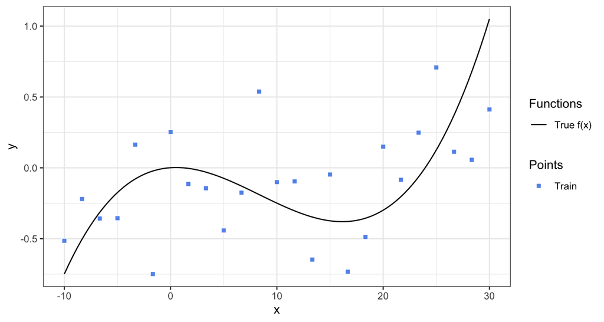

## Polynomial Fits of Degree 1, 3, and 15

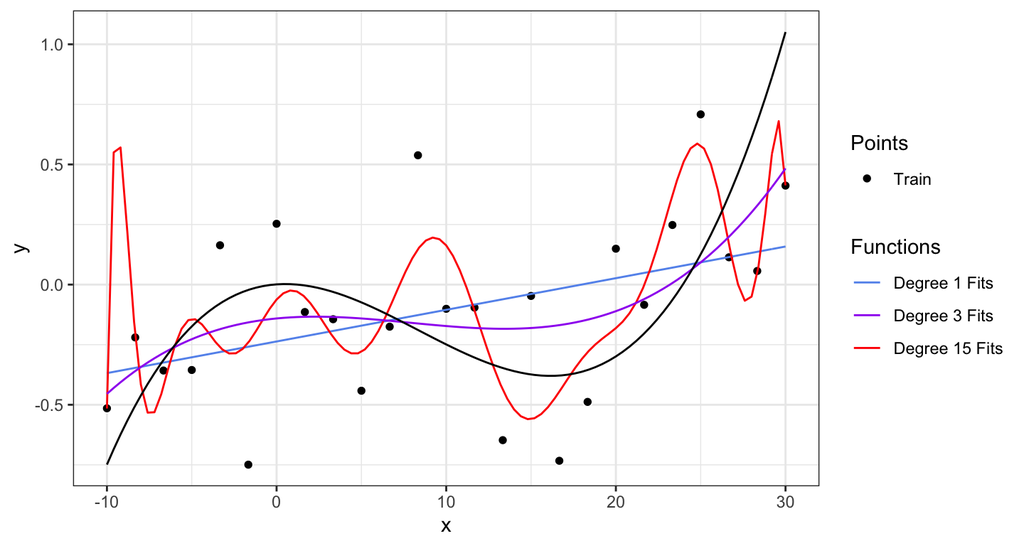

## Polynomial Fits of Degree 1, 3, and 15

Here are fits to a second randomly generated training set.

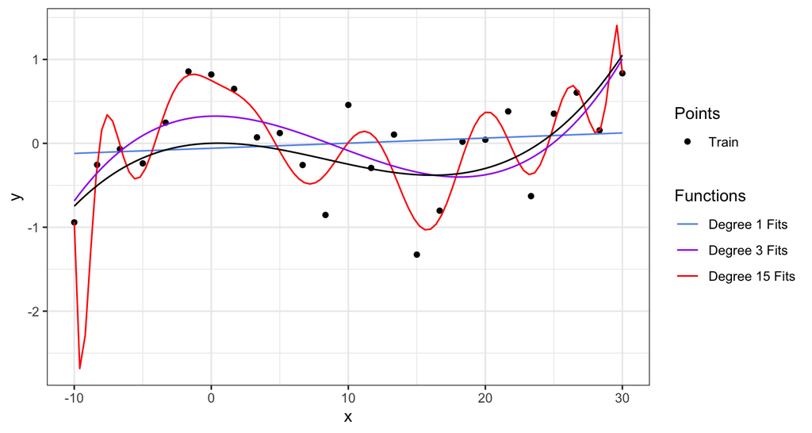

## Polynomial Fits of Degree 1, 3, and 15

Here's what fits look like across 100 randomly generated training samples.

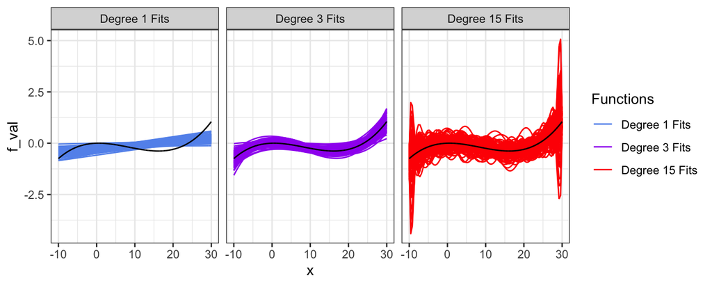

- **Bias:** Average (across training sets) value of prediction minus true function value
  - For many values of \(x\), Degree 1 fit is biased
  - Degree 3 and 15 fits are unbiased
- **Variance:** Variability of predicted values across training sets
  - Degree 15 fit has high variance
  - Degree 1 and 3 fits have lower variance

## Performance at a test point

We focus on measuring performance of our models at a particular input value, say \(x_0 = 20\).

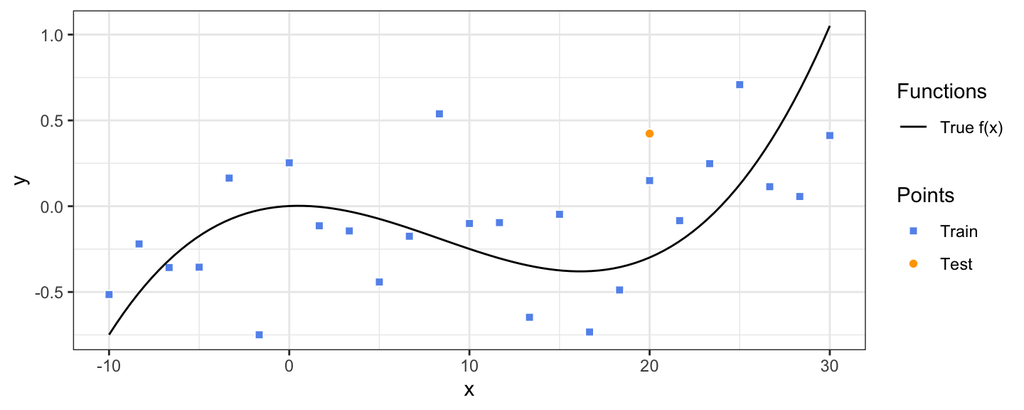

## Performance for Degree 1

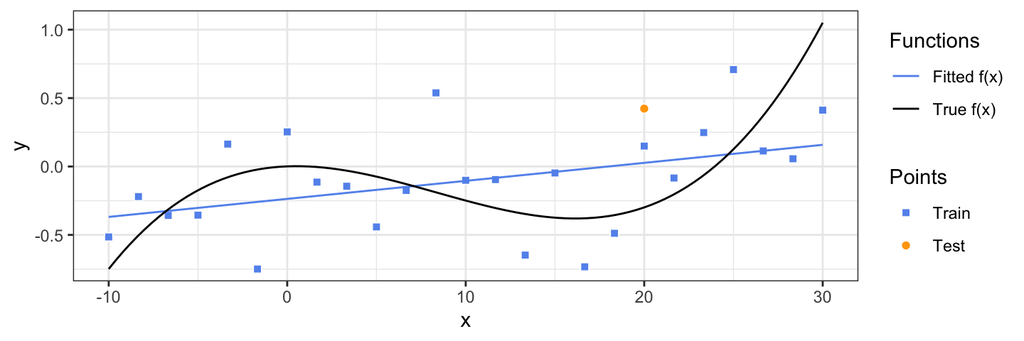

We record 3 things:

1. Difference between test observation and fitted value: \(y_0 - \hat{y}_0\)
   - Average of squared values across all train/test samples is **Expected test MSE**
2. Difference between fitted value and true function value: \(\hat{y}_0 - f(x_0)\)
   - Average across all train/test samples is the **Bias**
   - Variance across all train/test samples is the **Variance**
3. Difference between test observation and true function: \(y_0 - f(x_0)\).
   - Variance across all test samples is the **Model Error** (same as \(Var(\varepsilon)\))

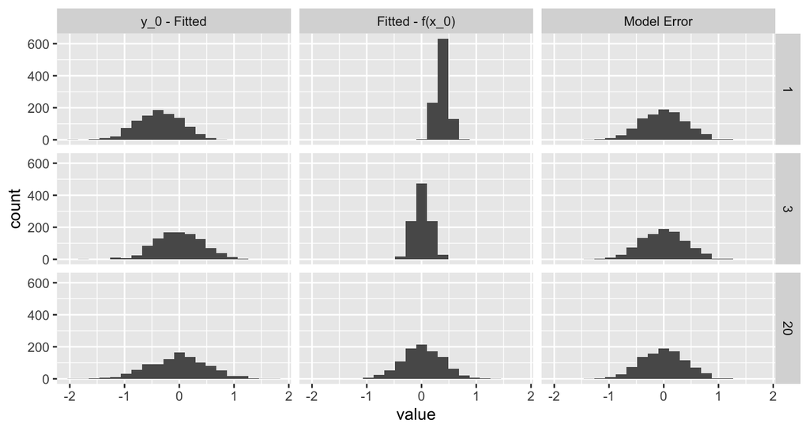

```
## # A tibble: 3 x 6
##   degree Expected_test_MSE     Bias Variance Model_Error Bias2_Var_Model_E…
##    <dbl>             <dbl>    <dbl>    <dbl>       <dbl>              <dbl>
## 1      1             0.306 0.365      0.0110       0.164              0.308
## 2      3             0.184 0.00181    0.0208       0.164              0.185
## 3     15             0.246 0.000988   0.0823       0.164              0.246
```